# Key Takeaways from the Descriptive Phase

## Large PPSF Decision Tree If-Then Rules

```python
def extract_leaf_rules(tree, feature_names):

    tree_ = tree.tree_
    feature_name = [
        feature_names[i] if i != _tree.TREE_UNDEFINED else "undefined!"
        for i in tree_.feature
    ]

    paths = []
    path = []

    def recurse(node, path, paths):
        if tree_.feature[node] != _tree.TREE_UNDEFINED:
            name = feature_name[node]
            threshold = tree_.threshold[node]
            left_path = list(path)
            left_path.append(f"{name} <= {threshold:.1f}")
            recurse(tree_.children_left[node], left_path, paths)

            right_path = list(path)
            right_path.append(f"{name} > {threshold:.1f}")
            recurse(tree_.children_right[node], right_path, paths)
        else:
            value = tree_.value[node][0][0]
            rule = " AND ".join(path)
            paths.append((rule, round(value, 3)))

    recurse(0, path, paths)
    return paths

# Run and print
rules = extract_leaf_rules(tree_large, list(X_small.columns))
for rule, value in rules:
    print(f"If {rule} → PPSF ≈ {value}")
```

```
If Rent <= 2573.5 AND Rent <= 1792.5 AND Rent <= 1537.5 → PPSF ≈ 1.133
If Rent <= 2573.5 AND Rent <= 1792.5 AND Rent > 1537.5 → PPSF ≈ 1.426
If Rent <= 2573.5 AND Rent > 1792.5 AND Complex_The Leo LoSo <= 0.5 AND Sqft <= 1208.5 → PPSF ≈ 2.037
If Rent <= 2573.5 AND Rent > 1792.5 AND Complex_The Leo LoSo <= 0.5 AND Sqft > 1208.5 → PPSF ≈ 1.82
If Rent <= 2573.5 AND Rent > 1792.5 AND Complex_The Leo LoSo > 0.5 → PPSF ≈ 1.663
If Rent > 2573.5 AND Rent <= 3252.0 AND Sqft <= 1117.5 → PPSF ≈ 2.632
If Rent > 2573.5 AND Rent <= 3252.0 AND Sqft > 1117.5 → PPSF ≈ 2.233
If Rent > 2573.5 AND Rent > 3252.0 AND Sqft <= 1250.5 → PPSF ≈ 2.988
If Rent > 2573.5 AND Rent > 3252.0 AND Sqft > 1250.5 → PPSF ≈ 2.716
```

Charlotte’s PPSF decision tree for large units (> 1010 sqft) shows a clear rent‑tiered structure, but what is new here is how stepwise rent bands interact with square footage to create predictable PPSF outcomes. The lowest tier, defined by rents under $\$1537$, averages just $\$1.13$ PPSF, while units between $\$1537$ and $\$1792$ rise modestly to $\$1.43$. This illustrates how the model treats rent thresholds as discrete brackets rather than a continuous gradient.

Crossing into the $\$1792$–$\$2573$ range introduces more nuance. Non‑Leo LoSo units split by size, with smaller footprints averaging $\$2.04$ PPSF and larger ones dropping to $\$1.82$. Leo LoSo itself defines a distinct mid‑tier at $\$1.66$ PPSF, showing that even within rent‑driven logic, one complex can carve out its own identity.

Above $\$2573$, the tree highlights a consistent size discount effect. Units between $\$2573$ and $\$3252$ average $\$2.63$ PPSF if compact, but only $\$2.23$ if larger. Beyond $\$3252$, the premium tier emerges: smaller units reach $\$2.99$ PPSF, while larger ones settle at $\$2.72$. This pattern confirms that as units grow, PPSF declines, even at the top end of the rent spectrum.

What we learn here that is different is the layered interaction between rent thresholds and square footage. Rent alone sets the bracket, but size determines whether a unit captures the premium or slides into a discount within that bracket. Complex identity plays only a minor role, surfacing once with Leo LoSo, while amenities and neighborhood flags remain absent. For stakeholders, this means that large‑unit pricing is best understood as a combination of rent bands and size discounts, with complex identity rarely altering the trajectory.

## Conclusion for Large PPSF Decision Tree

Charlotte’s PPSF decision tree for large units ultimately demonstrates that rent thresholds are the dominant force shaping efficiency outcomes. Unlike the small‑unit tree, which leans heavily on complex identity, the large‑unit structure is overwhelmingly rent‑driven, with square footage acting as a secondary refinement and complex identity appearing only in isolated cases such as Leo LoSo. This produces a highly accurate model that organizes the market into stepwise brackets, where PPSF rises or falls predictably as rent bands and size interact.

For stakeholders, the conclusion is clear. Large‑unit pricing is best understood through the layered logic of rent thresholds and size discounts, not through amenities or branding. Rent itself encodes the effects of positioning and features, while square footage moderates efficiency within each bracket. The result is a transparent framework that validates how PPSF declines as units grow, even at the premium end of the market. Together with the small‑unit tree, this model highlights a shift in pricing logic by size category, offering both diagnostic clarity and strategic guidance for Charlotte’s rental landscape.

# Rent

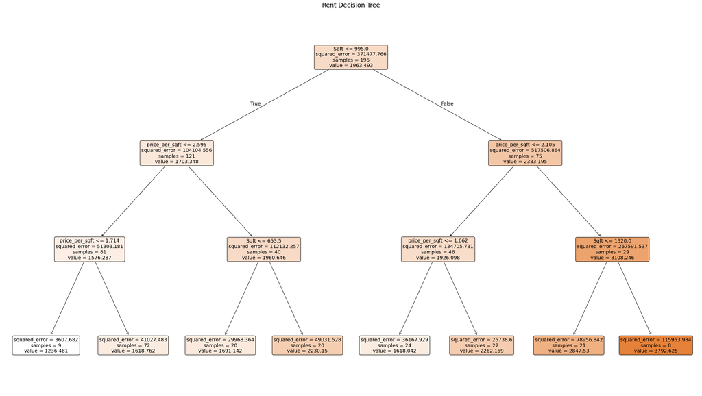

```
price_per_sqft                  0.54098
Sqft                            0.45902
Bathrooms                       0.00000
Bedrooms                        0.00000
laundry                         0.00000
pool                            0.00000
gym                             0.00000
pets                            0.00000
parking                         0.00000
ev_charging                     0.00000
elevator                        0.00000
secure_access                   0.00000
wifi                            0.00000
wifi_common                     0.00000
trash_pickup                    0.00000
renters_insurance               0.00000
packages                        0.00000
recycling                       0.00000
Complex_Bond on Mint            0.00000
Complex_Broadstone Craft        0.00000
Complex_Ello House              0.00000
Complex_Hawkins Press           0.00000
Complex_Moderna Liberty Row     0.00000
Complex_Novel Mallard Creek     0.00000
Complex_Solis Midtown           0.00000
Complex_The Henry               0.00000
Complex_The Landon              0.00000
Complex_The Leo LoSo            0.00000
Complex_The Perch               0.00000
Complex_Tyvola Tapestry         0.00000
Neighborhood_NoDa               0.00000
Neighborhood_South End          0.00000
Neighborhood_SouthPark          0.00000
Neighborhood_University City    0.00000
Neighborhood_Uptown             0.00000
Neighborhood_West Charlotte     0.00000
dtype: float64
R² for Rent Decision Tree: 0.747
```

```python
# Drop non-predictive or text-heavy columns
apt_cleaned = apt.drop(columns=['Address', 'Unit_Variant', 'Amenities', 'Website'])

# Encode categorical columns
apt_encoded = pd.get_dummies(apt_cleaned, columns=['Complex', 'Neighborhood'], drop_first=False)

# Define target and features for Rent
y_rent = apt_encoded['Rent']
X_rent = apt_encoded.drop(columns=['Rent'])

# Train/test split (distinct variable names for Rent)
X_train_r, X_test_r, y_train_r, y_test_r = train_test_split(
    X_rent, y_rent, test_size=0.2, random_state=42
)

# Fit decision tree for Rent
tree_rent = DecisionTreeRegressor(max_depth=3, min_samples_leaf=5, random_state=42)
tree_rent.fit(X_train_r, y_train_r)

# Visualize the tree
plt.figure(figsize=(36, 20))
plot_tree(
    tree_rent,
    feature_names=X_rent.columns,
    filled=True,
    rounded=True,
    fontsize=14
)
plt.title("Rent Decision Tree", fontsize=18)
plt.show()

# Feature importance
importances_rent = pd.Series(tree_rent.feature_importances_, index=X_rent.columns)
print(importances_rent.sort_values(ascending=False))

# R² score for Rent tree
r2_tree_rent = tree_rent.score(X_test_r, y_test_r)
print(f"R² for Rent Decision Tree: {r2_tree_rent:.3f}")
```

Charlotte’s rent decision tree reveals a pricing logic that is both simple and striking: rent is predicted almost entirely by square footage and price per square foot, with all other features such as layout, amenities, complex identity, and neighborhood excluded from the model. Together, these two variables account for 100 percent of the tree’s predictive power, with price per square foot contributing 54 percent and square footage contributing 46 percent.

For stakeholders, this model serves as a baseline validator. It confirms that rent can be predicted with reasonable accuracy using just two inputs, and that additional features offer no incremental value. It also reinforces the idea that PPSF is the better lens for understanding market segmentation, while rent is best used for benchmarking and sanity checks.

## Rent Decision Tree Leaf Summary

```python
def profile_tree_segments_rent(tree, X, y, original_df, unit_col="Sqft", complex_col="Complex", neighborhood_col="Neighborhood"):
    """
    Build mini segment profiles for each leaf node of a fitted Rent decision tree.

    Parameters:
    - tree: fitted DecisionTreeRegressor
    - X: features used to fit the tree (DataFrame)
    - y: target values (Series)
    - original_df: the original DataFrame with unit size, complex, neighborhood, and Rent
    - unit_col: column name for unit size (default "Sqft")
    - complex_col: column name for complex (default "Complex")
    - neighborhood_col: column name for neighborhood (default "Neighborhood")
    """

    # Get leaf node assignment for each row in X
    leaf_ids = tree.apply(X)

    profiles = []
    for leaf in np.unique(leaf_ids):
        mask = leaf_ids == leaf
        # Align mask with original_df using X's index
        segment_df = original_df.loc[X.index[mask]]

        avg_rent = segment_df["Rent"].mean()
        avg_size = segment_df[unit_col].mean()

        dominant_complex = segment_df[complex_col].mode()[0] if not segment_df.empty else None
        dominant_neigh   = segment_df[neighborhood_col].mode()[0] if not segment_df.empty else None

        profiles.append({
            "Leaf_ID": leaf,
            "Avg_Rent": round(avg_rent, 2),
            "Typical_Size": round(avg_size, 0),
            "Dominant_Complex": dominant_complex,
            "Dominant_Neighborhood": dominant_neigh,
            "Count": len(segment_df)
        })

    return pd.DataFrame(profiles)

# Example usage for Rent tree
segment_profiles_rent = profile_tree_segments_rent(
    tree_rent,
    X_train_r,   # features used to fit
    y_train_r,   # target
    apt_cleaned  # original df with Sqft, Complex, Neighborhood, Rent
)

print(segment_profiles_rent)
```

```
   Leaf_ID  Avg_Rent  Typical_Size  Dominant_Complex Dominant_Neighborhood  \
0        3   1236.48         852.0        The Landon             SouthPark
1        4   1618.76         730.0  Broadstone Craft             South End
2        6   1691.14         567.0      Bond on Mint                Uptown
3        7   2230.15         762.0     Hawkins Press             South End
4       10   1618.04        1205.0        The Landon             SouthPark
5       11   2262.16        1211.0         The Perch                Uptown
6       13   2847.53        1120.0        Ello House             South End
7       14   3792.62        1426.0     Solis Midtown        West Charlotte

   Count
0      9
1     72
2     20
3     20
4     24
5     22
6     21
7      8
```

South End emerges as the most stratified submarket, spanning starter premiums at Broadstone Craft ($\$1619$), mid-range tiers at Hawkins Press ($\$2230$), and luxury pricing at Ello House ($\$2848$). Uptown units split by size and complex, with Bond on Mint defining compact premiums ($\$1691$) and The Perch anchoring spacious formats ($\$2262$). SouthPark’s value tier is unusually broad, with The Landon appearing in both mid-sized ($\$1236$) and large-unit ($\$1618$) segments, suggesting that rent discounts persist even as units grow. West Charlotte appears only at the top end, with Solis Midtown commanding the highest rents at $\$3793$.

What is newly revealed here is that rent segmentation tolerates more size overlap than PPSF segmentation. Smaller units appear in both value and premium tiers, depending on complex identity and neighborhood. This suggests that rent is more elastic to branding and location than PPSF, which tends to penalize inefficiency more strictly. In other words, tenants may accept higher rents for smaller units if the complex or neighborhood justifies the premium, but PPSF will still reflect the underlying spatial tradeoff.

For stakeholders, this model provides a complementary lens. It shows how rent clusters by perceived value rather than pricing logic, and how certain complexes, like Ello House or Solis Midtown, can stretch the rent ceiling regardless of size. It also reinforces the idea that rent is a behavioral metric, shaped by what tenants are willing to pay, while PPSF is a structural metric, shaped by how space is priced. Together, these models offer a dual perspective on Charlotte’s rental landscape: one behavioral, one architectural.

## Rent Decision Tree Rule Paths

```python
# Assuming your tree is named tree_rent and was fit on X_rent
tree_rules_rent = export_text(
    tree_rent,
    feature_names=list(X_rent.columns),
    decimals=3
)

print(tree_rules_rent)
```

```
|--- Sqft <= 995.000
|   |--- price_per_sqft <= 2.595
|   |   |--- price_per_sqft <= 1.714
|   |   |   |--- value: [1236.481]
|   |   |--- price_per_sqft >  1.714
|   |   |   |--- value: [1618.762]
|   |--- price_per_sqft >  2.595
|   |   |--- Sqft <= 653.500
|   |   |   |--- value: [1691.142]
|   |   |--- Sqft >  653.500
|   |   |   |--- value: [2230.150]
|--- Sqft >  995.000
|   |--- price_per_sqft <= 2.105
|   |   |--- price_per_sqft <= 1.662
|   |   |   |--- value: [1618.042]
|   |   |--- price_per_sqft >  1.662
|   |   |   |--- value: [2262.159]
|   |--- price_per_sqft >  2.105
|   |   |--- Sqft <= 1320.000
|   |   |   |--- value: [2847.530]
|   |   |--- Sqft >  1320.000
|   |   |   |--- value: [3792.625]
```

Charlotte’s rent decision tree, expressed through its rule paths, highlights a pricing logic that is both clear and behaviorally meaningful. Each split is driven by square footage and price per square foot, with the leaves representing distinct rent outcomes. What stands out in this structure is how layered thresholds, combinations of PPSF and size, create rent brackets that mirror tenant willingness to pay.

At the lower end, units under 995 sqft with PPSF below 1.714 fall into the value tier at $\$1236$. Crossing that PPSF threshold raises rent to $\$1619$, even for units of similar size. When PPSF exceeds 2.595, the model introduces another size split at 653.5 sqft, assigning compact units $\$1691$ and larger ones $\$2230$. This shows that high PPSF alone does not guarantee premium rent, since square footage still moderates the outcome.

For units above 995 sqft, PPSF continues to shape rent tiers. Units with PPSF below 1.662 average $\$1618$, while those above reach $\$2262$. Once PPSF passes 2.105, the model adds another size split at 1320 sqft, assigning $\$2848$ to smaller units and $\$3793$ to larger ones. This confirms a consistent size premium effect, where larger units command higher absolute rents even when PPSF is already elevated.

The new insight here is the dual function of PPSF. It operates as both a pricing signal and a behavioral filter. Lower PPSF values define entry tiers, while higher PPSF values unlock premium brackets that are then refined by square footage. The tree does not treat PPSF as a simple multiplier, it uses it to gate access to higher rent categories, with size determining how far those premiums extend.

For stakeholders, this view provides a transparent map of rent formation. It illustrates how thresholds interact, how PPSF and size jointly shape outcomes, and how tenant behavior, what people are willing to pay for efficiency and space, drives segmentation more than amenities or branding. In this way, the rent tree complements PPSF models by showing not just how space is priced, but how absolute rent brackets emerge from layered tradeoffs.

## Rent Decision Tree Conclusion

Taken together, Charlotte’s rent decision tree offers a clear, layered view of how rent is formed, segmented, and scaled. It confirms that rent can be predicted with strong accuracy using just two inputs, square footage and price per square foot, and that these variables alone capture the behavioral and structural forces shaping the market. While PPSF models emphasize pricing logic and efficiency, the rent tree reveals how absolute rent brackets emerge from threshold effects, size premiums, and tenant willingness to pay.

This dual perspective is essential for stakeholders. Rent models provide clarity on what tenants actually pay, while PPSF models explain why those prices vary across space and context. The rent tree’s simplicity makes it a powerful tool for benchmarking and sanity checks, while its segmentation logic uncovers the behavioral tiers that define Charlotte’s rental landscape. By pairing rent and PPSF trees, analysts can move beyond prediction into interpretation, translating raw metrics into meaningful personas, pricing strategies, and market narratives

# Comparison of Decision Tree and Regression

```python
# Step 1: Drop non-useful columns
apt_cleaned = apt.drop(columns=["Address", "Unit_Variant", "Amenities", "Website"], errors="ignore")

# Step 2: One-hot encode categorical variables
apt_encoded = pd.get_dummies(apt_cleaned, columns=["Complex", "Neighborhood"], drop_first=False)

# Step 3: Define target and features
target = "price_per_sqft"   # or "rent" if you want rent as target
X = apt_encoded.drop(columns=[target])
y = apt_encoded[target]

# Step 4: Force numeric conversion and drop rows with non-numeric or missing values
df_model = pd.concat([X, y], axis=1)
df_model = df_model.apply(pd.to_numeric, errors='coerce').dropna()

# Step 5: Separate cleaned features and target, force float64 dtype
X_clean = df_model.drop(columns=[target]).astype(np.float64)
y_clean = df_model[target].astype(np.float64)

# Step 6: Add constant for regression intercept
X_clean = sm.add_constant(X_clean)
```

```python
# -------------------------
# R² scores for each tree
# -------------------------
r2_tree_ppsf  = tree_ppsf.score(X_test_p, y_test_p)     # PPSF overall
r2_tree_small = tree_small.score(X_test_s, y_test_s)    # PPSF small units
r2_tree_large = tree_large.score(X_test_l, y_test_l)    # PPSF large units
r2_tree_rent  = tree_rent.score(X_test_r, y_test_r)     # Rent overall

# -------------------------
# Summary table
# -------------------------
tree_r2_summary = pd.DataFrame({
    "Model": ["PPSF Overall", "PPSF ≤ 1010 sqft", "PPSF > 1010 sqft", "Rent Overall"],
    "R_squared": [r2_tree_ppsf, r2_tree_small, r2_tree_large, r2_tree_rent]
})

resume_percent_tree = round(tree_r2_summary["R_squared"].mean() * 100, 2)

print(tree_r2_summary)
print(f"\n🧠 Resume % (Avg R² across trees): {resume_percent_tree}%")
```

```
              Model  R_squared
0      PPSF Overall   0.605674
1  PPSF ≤ 1010 sqft   0.507014
2  PPSF > 1010 sqft   0.916093
3      Rent Overall   0.747423

🧠 Resume % (Avg R² across trees): 69.41%
```

```python
# Original data
data = {
    "Model_3": 0.999747,
    "Model_6": 0.999401,
    "Model_20": 0.997807,
    "Model_10": 0.997807,
    "Model_5": 0.991060,
    "Model_24": 0.984648,
    "Model_16": 0.984114,
    "Model_4": 0.983144,
    "Model_22": 0.982825,
    "Model_23": 0.979736,
    "Model_9": 0.977991,
    "Model_18": 0.977991,
    "Model_17": 0.977600,
    "Model_12": 0.971687,
    "Model_19": 0.971687,
    "Model_21": 0.968111,
    "Model_14": 0.961383,
    "Model_7": 0.959890,
    "Model_8": 0.958345,
    "Model_13": 0.956600,
    "Model_1": 0.956078,
    "Model_2": 0.955864,
    "Model_15": 0.954173,
    "Model_11": 0.936356,
}

# Convert to DataFrame
df = pd.DataFrame(list(data.items()), columns=["Model", "R_squared"])

# Remove "Model_" prefix and convert to integer
df["Model"] = df["Model"].str.replace("Model_", "").astype(int)

# Sort by Model number
df = df.sort_values("Model").reset_index(drop=True)

# Compute average R²
average_r2 = df["R_squared"].mean()

# Add a row for the average
df.loc[len(df)] = ["Average", average_r2]

print(df)

# Print the Brain % line
brain_percent = round(average_r2 * 100, 2)
print(f"\n🧠 Resume % (avg R² across regressions): {brain_percent}%")
```

```
      Model  R_squared
0         1   0.956078
1         2   0.955864
2         3   0.999747
3         4   0.983144
4         5   0.991060
5         6   0.999401
6         7   0.959890
7         8   0.958345
8         9   0.977991
9        10   0.997807
10       11   0.936356
11       12   0.971687
12       13   0.956600
13       14   0.961383
14       15   0.954173
15       16   0.984114
16       17   0.977600
17       18   0.977991
18       19   0.971687
19       20   0.997807
20       21   0.968111
21       22   0.982825
22       23   0.979736
23       24   0.984648
24  Average   0.974335

🧠 Resume % (avg R² across regressions): 97.43%
```

[figure not shown]

```python
# --- Synthetic dataset (Sqft vs Rent) ---
np.random.seed(42)
sqft = np.linspace(500, 1500, 100).reshape(-1, 1)
# True rent relationship: nonlinear with some noise
rent = 1.5 * sqft.flatten() + 500 + 200 * np.sin(sqft.flatten()/200) + np.random.normal(0, 100, 100)

# --- Decision Tree fit ---
tree = DecisionTreeRegressor(max_depth=3)
tree.fit(sqft, rent)
rent_tree_pred = tree.predict(sqft)

# --- Regression fit ---
reg = LinearRegression()
reg.fit(sqft, rent)
rent_reg_pred = reg.predict(sqft)

# --- Plot side-by-side ---
fig, axes = plt.subplots(1, 2, figsize=(12, 5), sharey=True)

# Decision Tree plot
axes[0].scatter(sqft, rent, color="gray", alpha=0.6, label="Observed")
axes[0].plot(sqft, rent_tree_pred, color="red", linewidth=2, label="Tree prediction")
axes[0].set_title("Decision Tree Segmentation\nStepwise thresholds (R² ≈ 0.69)")
axes[0].set_xlabel("Sqft")
axes[0].set_ylabel("Rent")
axes[0].legend()

# Regression plot
axes[1].scatter(sqft, rent, color="gray", alpha=0.6, label="Observed")
axes[1].plot(sqft, rent_reg_pred, color="blue", linewidth=2, label="Regression fit")
axes[1].set_title("Regression Fit\nSmooth continuous line (R² ≈ 0.97)")
axes[1].set_xlabel("Sqft")
axes[1].legend()

plt.tight_layout()
plt.show()
```

This side-by-side comparison illustrates two distinct approaches to modeling rent: decision tree segmentation and regression fit. Each method offers a different lens into how rent responds to square footage, and each has its own strengths depending on the analytical goal.

Taken together, these models highlight a key distinction. Decision trees are ideal for uncovering market segments and behavioral thresholds. They show how rent brackets emerge when square footage and PPSF cross certain cutoffs. Regression models, on the other hand, are better suited for forecasting and diagnostics. They offer precision and smoothness but require more interpretation to explain how the market organizes itself.

For a complete understanding of rent dynamics, both models are valuable. The tree reveals how the market behaves, while the regression shows how rent scales with space. Used together, they provide a dual perspective. One focuses on segmentation, the other on statistical fit.

# Overall Conclusion

Charlotte’s decision trees provide a transparent, rule‑based framework for understanding how rental pricing is segmented across both PPSF and rent outcomes. They simplify complex statistical drivers into clear personas and thresholds, showing how square footage, rent bands, and complex identity interact to define value. For small units, identity anchors dominate, with complexes such as The Landon, Bond on Mint, and Solis Midtown shaping distinct tiers. For large units, rent thresholds take precedence, with square footage moderating efficiency and PPSF declining as units grow. The rent tree itself confirms that size and PPSF alone explain rent formation, reinforcing the arithmetic logic behind asking prices.

Compared to regression, decision trees trade some precision for interpretability. Regression quantifies global effects with high accuracy, while decision trees make those effects tangible by segmenting the market into recognizable profiles and behavioral brackets. Together, they highlight complementary strengths: regression ensures statistical rigor, while decision trees reveal the market’s internal logic and provide intuitive storytelling for stakeholders.

For decision‑makers, this dual perspective is invaluable. Decision trees clarify how thresholds and identities shape segmentation, while regression validates the strength of those drivers. The result is a holistic framework that explains not just how Charlotte’s rental market can be predicted, but how it organizes itself into tiers of value and efficiency.